# mars_pet

Yuang Guo

2023-10-21

#environment setting ##clean

```r
  rm(list = ls()) # Clear all files from your environment
  gc()            # Clear unused memory
```

```
##          used (Mb) gc trigger (Mb) max used (Mb)
## Ncells 522210 27.9    1161835 62.1   660385 35.3
## Vcells 951786  7.3    8388608 64.0  1771562 13.6
```

```r
  cat("\f")       # Clear the console
```

```r
  graphics.off()  # Clear all graphs
```

##package

```r
packages <- c("psych",       # quick summary stats for data exploration,
              "stargazer",   # summary stats,
              "summarytools",# summary stats,
              "naniar",      # for visualisation of missing data,
              "visdat",      # for visualisation of missing data,
              "VIM",         # for visualisation of missing data,
              "DataExplorer",# for visualisation of missing data,
              "tidyverse",   # data manipulation like selecting variables,
              "fastDummies", # Create dummy variables using fastDummies,
              "corrplot",    # correlation plots,
              "ggplot2",     # graphing,
              "data.table",  # reshape for graphing,
              "car",
              "seasonal",
              "fpp3",
              "tsibble",    # vif for multicollinearity
              "cli",
              "crayon",
              "dplyr",
              "fable",
              "fabletools",
              "feasts",
              "lubridate",
              "magrittr",
              "purrr",
              "rstudioapi",
              "tibble",
              "tidyr",
              "tsibbledata",
              "latex2exp",
              "GGally",
              "broom",
              "zoo"
              )


for (i in 1:length(packages)) {
  if (!packages[i] %in% rownames(installed.packages())) {
    install.packages(packages[i]
                     , repos = "http://cran.rstudio.com/"
                     , dependencies = TRUE
                     )
  }
  library(packages[i], character.only = TRUE)
}
```

```
##  Hlavac, Marek (2022). stargazer: Well-Formatted Regression and Summary Statistics Tables.
```

```
##  R package version 5.2.3. https://CRAN.R-project.org/package=stargazer
```

```
## VIM is ready to use.
```

```
## Suggestions and bug-reports can be submitted at: https://github.com/statistikat/VIM/issues
```

[output not shown]

```r
rm(packages)
```

#data introduction ##import data

```r
setwd(getwd())
rawdata = read.csv("petfood_retail_table.csv")
```

#Monthly Time series data prediction

```r
#create dataset for manufacturer id and monthly data aggregate
manu_mars <- rawdata |> filter(MANU_ID == "MARS") |>
                        mutate(DATE = yearmonth(DATE)) |>
                        mutate(transaction = PRICE*UNITS) |>
                        group_by(DATE) |>
                        summarise(transaction = sum(transaction))

manu_mars_monthly_tsibble <- as_tsibble(manu_mars, index = "DATE")
manu_mars_monthly_tsibble
```

```
## # A tsibble: 42 x 2 [1M]
##        DATE transaction
##       <mth>       <dbl>
##  1 2019 Jul       256.
##  2 2019 Aug       188.
##  3 2019 Sep       205.
##  4 2019 Oct       148.
##  5 2019 Nov        96.8
##  6 2019 Dec       198.
##  7 2020 Jan       114.
##  8 2020 Feb        78.9
##  9 2020 Mar       231.
## 10 2020 Apr        82.9
## # ℹ 32 more rows
```

```r
##turn to tsibble
```

##easy autolpot map

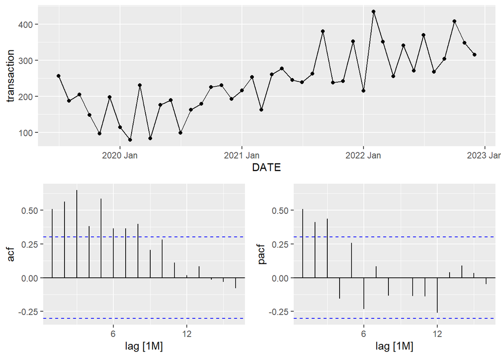

```r
manu_mars_monthly_tsibble |> filter(!is.na(transaction)) |>                                                                                gg_tsdisplay(transaction,plot_type = "partial")
```

use gg_tsdisplay to show the ACF and PACF There is no evidence of changing variance, so we will not do a Box-Cox transformation.

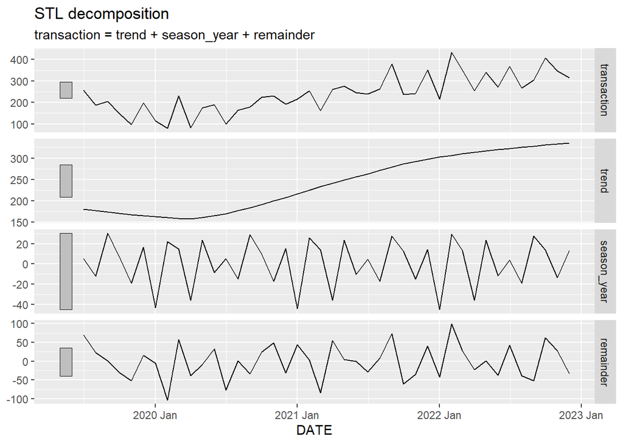

```r
monthly_dcmp <- manu_mars_monthly_tsibble |> filter(!is.na(transaction)) |>
                model(stl = STL(transaction))
components(monthly_dcmp) |> autoplot()
```

I don’t think we will try log transformation in this place maybe we can try?? First we should remove inflation??

KPSS test first

```r
manu_mars_monthly_tsibble |>
  features(transaction, unitroot_kpss)
```

```
## # A tibble: 1 × 2
##   kpss_stat kpss_pvalue
##       <dbl>       <dbl>
## 1     0.979        0.01
```

Consequently, small p-values (e.g., less than 0.05) suggest that differencing is required.

We need to make difference first to eliminate the seasonal influence using the unitroots

```r
manu_mars_monthly_tsibble |> features(transaction, unitroot_nsdiffs)
```

```
## # A tibble: 1 × 1
##   nsdiffs
##     <int>
## 1       0
```

```r
manu_mars_monthly_tsibble |> features(transaction, unitroot_ndiffs)
```

```
## # A tibble: 1 × 1
##   ndiffs
##    <int>
## 1      1
```

0 suggests no seasonal differencing 1 suggests we should do both a first difference. Then let’s do first differencing and test kpss again finally we replace the data

```r
manu_mars_monthly_tsibble |> mutate(transaction = difference(transaction)) |>
                             features(transaction, unitroot_kpss)
```

```
## # A tibble: 1 × 2
##   kpss_stat kpss_pvalue
##       <dbl>       <dbl>
## 1    0.0893         0.1
```

```r
manu_mars_monthly_tsibble_first_differencing <- manu_mars_monthly_tsibble |> mutate(transaction = difference(transaction))
```

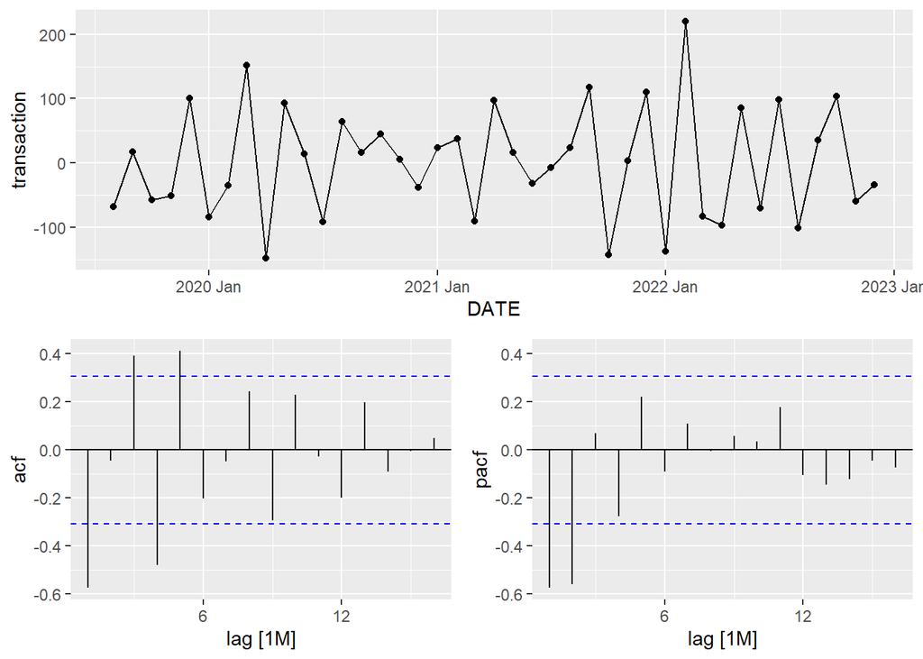

```r
manu_mars_monthly_tsibble_first_differencing |> filter(!is.na(transaction)) |>                                                                                gg_tsdisplay(transaction,plot_type = "partial")
```

But acf is still awful in the previous periods Then we have solved the data problems now It’s enough!!!! Based on this map we can choose p,q for ARIMA(p,d,q) When looking at ACF plot, we ignore the long spike at lag 0 For PACF, the line usually starts at 1. In this ACF and PACF maps, not tail off, but only cut off, we find the spike for ACF shows MA(1) and MA(3) we find the spike for PACF shows AR(1) and AR(2) Then is the combination of those a ARMA models Then because we have first_differencing for once, we will have ARIMA(p,1,q) model for this regression model Then we can create our model ##ARIMA models

```r
arima_fit <- manu_mars_monthly_tsibble_first_differencing |>
             filter(!is.na(transaction)) |>
             model(
                   arima110 = ARIMA(transaction ~ pdq(1,1,0)),
                   arima013 = ARIMA(transaction ~ pdq(0,1,3)),
                   arima011 = ARIMA(transaction ~ pdq(0,1,1)),
                   arima210 = ARIMA(transaction ~ pdq(2,1,0)),
                   stepwise = ARIMA(transaction),
                   search = ARIMA(transaction, stepwise=FALSE)
  )
arima_fit
```

```
## # A mable: 1 x 6
##                    arima110                  arima013     arima011
##                     <model>                   <model>      <model>
## 1 <ARIMA(1,1,0)(1,0,0)[12]> <ARIMA(0,1,3)(1,0,0)[12]> <NULL model>
## # ℹ 3 more variables: arima210 <model>, stepwise <model>, search <model>
```

```r
glance(arima_fit) |> arrange(AICc) |> dplyr::select(.model:BIC)
```

```
## # A tibble: 5 × 6
##   .model   sigma2 log_lik   AIC  AICc   BIC
##   <chr>     <dbl>   <dbl> <dbl> <dbl> <dbl>
## 1 arima013  3127.   -220.  449.  451.  458.
## 2 stepwise  3029.   -222.  453.  454.  460.
## 3 search    3029.   -222.  453.  454.  460.
## 4 arima210  5183.   -228.  464.  465.  471.
## 5 arima110 11688.   -244.  495.  495.  500.
```

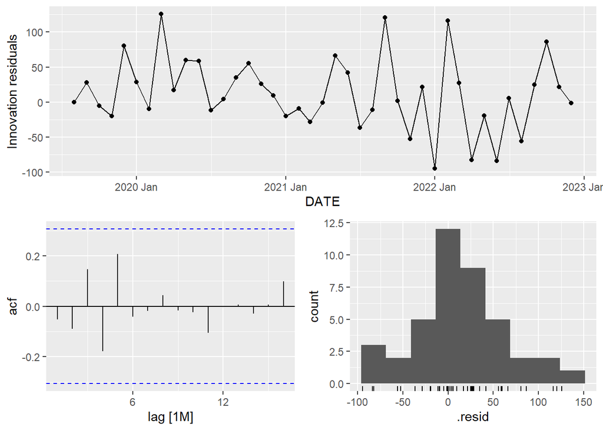

```r
arima_fit |> dplyr::select(arima013) |> gg_tsresiduals()
```

The residuals of this model looks good

```r
augment(arima_fit) |> filter(.model == "arima013") |> features(.innov, ljung_box, lag = 10, dof = 3)
```

```
## # A tibble: 1 × 3
##   .model   lb_stat lb_pvalue
##   <chr>      <dbl>     <dbl>
## 1 arima013    5.33     0.620
```

```r
forecast_arima <- arima_fit |> forecast(h= "2 years") |> filter(.model=='arima013')
augment(arima_fit)
```

```
## # A tsibble: 246 x 6 [1M]
## # Key:       .model [6]
##    .model       DATE transaction .fitted    .resid    .innov
##    <chr>       <mth>       <dbl>   <dbl>     <dbl>     <dbl>
##  1 arima110 2019 Aug       -68.3  -68.3    -0.0683   -0.0683
##  2 arima110 2019 Sep        17.5  -40.7    58.2      58.2
##  3 arima110 2019 Oct       -57.3  -41.7   -15.5     -15.5
##  4 arima110 2019 Nov       -51.2  -10.6   -40.6     -40.6
##  5 arima110 2019 Dec       101.   -42.1   143.      143.
##  6 arima110 2020 Jan       -83.5   -9.47  -74.0     -74.0
##  7 arima110 2020 Feb       -35.2   36.2   -71.4     -71.4
##  8 arima110 2020 Mar       152.   -51.7   204.      204.
##  9 arima110 2020 Apr      -148.    13.8  -162.     -162.
## 10 arima110 2020 May        92.7   53.8    38.9      38.9
## # ℹ 236 more rows
```

##CHECK FOR THE SEASONALITY

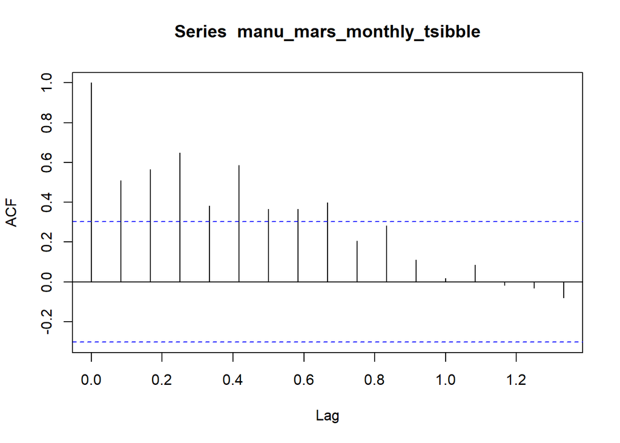

```r
acf(manu_mars_monthly_tsibble)
```

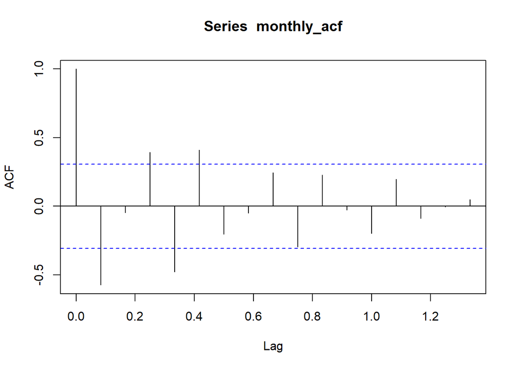

```r
monthly_acf <- manu_mars_monthly_tsibble_first_differencing |> filter(!is.na(transaction))
acf(monthly_acf)
```

```r
#still a little bit seasonality but not seasonal differencing! Fuck I have ruined all the thing
```

##another way to check the seasonality

```r
Box.test(manu_mars_monthly_tsibble$transaction, type = "Ljung-Box")
```

```
##
##  Box-Ljung test
##
## data:  manu_mars_monthly_tsibble$transaction
## X-squared = 11.672, df = 1, p-value = 0.0006345
```

##auto.arima

```r
final_arima_model <- forecast::auto.arima(manu_mars_monthly_tsibble, stepwise = FALSE, approximation = FALSE, seasonal = TRUE)
summary(final_arima_model)
```

```
## Series: manu_mars_monthly_tsibble
## ARIMA(2,1,0)(1,0,0)[12]
##
## Coefficients:
##           ar1      ar2     sar1
##       -0.9249  -0.5523  -0.3537
## s.e.   0.1255   0.1256   0.1717
##
## sigma^2 = 3029:  log likelihood = -222.34
## AIC=452.67   AICc=453.78   BIC=459.53
##
## Training set error measures:
##                    ME    RMSE      MAE       MPE     MAPE     MASE         ACF1
## Training set 8.373443 52.3515 40.08884 -2.267692 18.48982 0.442327 -0.003531046
```

##TRYING TO EXPLAIN THIS MODEL

??how to show the interval on the graph ??how to add the first differencing Then lets add back the trend

trying to write some analysis on that

Then is to draw our prediction maps ##FINAL MODEL AND PREDICTION

```r
final_arima_model <- forecast::auto.arima(manu_mars_monthly_tsibble, stepwise = FALSE, approximation = FALSE, seasonal = TRUE)
forecast_arima <- forecast(final_arima_model, h = 24)
forecast_arima
```

```
##          Point Forecast    Lo 80    Hi 80    Lo 95    Hi 95
## Jan 2023       390.2214 319.6875 460.7553 282.3491 498.0937
## Feb 2023       284.6388 213.9064 355.3713 176.4629 392.8148
## Mar 2023       325.0023 249.4063 400.5983 209.3883 440.6164
## Apr 2023       364.2830 277.3455 451.2205 231.3235 497.2425
## May 2023       322.9356 234.5220 411.3492 187.7186 458.1526
## Jun 2023       355.0248 261.0190 449.0305 211.2554 498.7942
## Jul 2023       319.5221 220.1846 418.8595 167.5986 471.4455
## Aug 2023       351.9698 249.9599 453.9797 195.9592 507.9804
## Sep 2023       342.8266 236.1096 449.5437 179.6170 506.0363
## Oct 2023       304.7467 194.2300 415.2634 135.7260 473.7674
## Nov 2023       325.0898 211.4058 438.7738 151.2251 498.9545
## Dec 2023       338.2101 220.6297 455.7905 158.3864 518.0338
## Jan 2024       310.6915 193.0701 428.3128 130.8052 490.5777
## Feb 2024       348.1087 227.6186 468.5988 163.8350 532.3824
## Mar 2024       334.2614 212.1717 456.3510 147.5413 520.9814
## Apr 2024       319.9305 197.1580 442.7030 132.1662 507.6948
## May 2024       334.7223 209.8606 459.5841 143.7628 525.6819
## Jun 2024       323.4591 197.3900 449.5282 130.6531 516.2652
## Jul 2024       335.8440 208.6441 463.0439 141.3086 530.3795
## Aug 2024       324.4787 195.6661 453.2913 127.4769 521.4806
## Sep 2024       327.7048 197.7163 457.6933 128.9046 526.5050
## Oct 2024       341.1196 209.8593 472.3798 140.3743 541.8648
## Nov 2024       333.9787 201.3374 466.6200 131.1213 536.8361
## Dec 2024       329.3175 195.4791 463.1558 124.6294 534.0056
```

```r
#manu_mars_monthly_tsibble |> autoplot(transaction) + autolayer(transacto)
#colnames(forecast_arima)
#manu_mars_monthly_tsibble |> autoplot(transaction) + autolayer(forecast_arima)
```

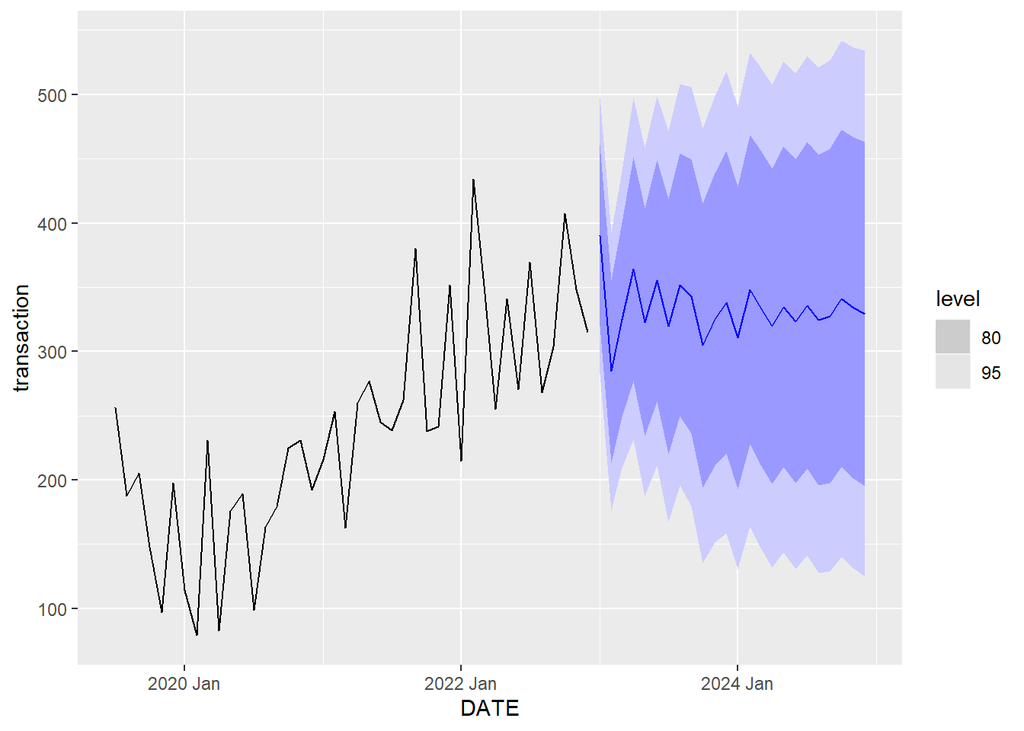

```r
la <- manu_mars_monthly_tsibble |>
    model(auto_arima = ARIMA(transaction ~ 0 + pdq(2,1,0) + PDQ(1,0,0))) |>
    forecast(h = 24)
# rewrite that into a model
manu_mars_monthly_tsibble |>
    model(auto_arima = ARIMA(transaction ~ 0 + pdq(2,1,0) + PDQ(1,0,0))) |>
    forecast(h = 24) |>
    autoplot(manu_mars_monthly_tsibble)
```

```r
#augment(la)
```

It’s weird, I use two ways to show the data there???

##predictioN

SLIDES AND DRAFT

I need to summarize the model and figure out when to use in the model.

#REVISION should we remove inflation SHOULD WE CONCERNED ABOUT THWE RANDOM FOREST SHOULD WE ADD SOME DIFFERENT PREDICTIONS FOR OTHERS COMPANY SHOULD WE ADD THE PLOT TOGETHER TRYING TO COMPARE SOMETHING

#JUST SOME LITTLE TRYINGS(IGNORE)

BE CAREFUL TO DEAL WITH THE FIRST MISSING DATA IN DIFFRENCING USING !is.na(factor) ##use multiple models to predict

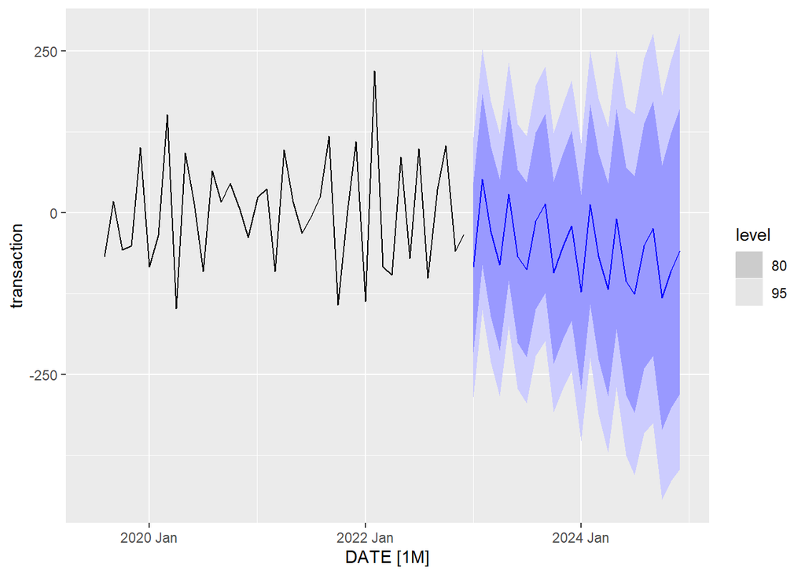

```r
#then is prediction, together with metrics  little bit seasonal
#arima ets each has lots of arguments
#add some senario forecastings
fit_monthly <- manu_mars_monthly_tsibble_first_differencing |> filter(!is.na(transaction)) |> model(
               ETS = ETS(transaction ~ error("A") + trend("A") + season("A"))
               )
monthly_forecast <- forecast(fit_monthly, h = 24)
manu_mars_monthly_tsibble_first_differencing |> autoplot(transaction) + autolayer(monthly_forecast)  #add something else
```

How can we add the differencing data back? How to use that: Hyndman-Khandakar algorithm for automatic ARIMA modelling

#NO WEEKLY DATA ANYMORE

##test portmanteau test ? AIC BIC AICc

#Weekly time series data prediction

##data set create

kpss first

## 3 breakdowns for trend